# Exploring and modeling data on American fuel consumption

#### The fuel dataset

```
## [1] "Drivers" "FuelC"   "Income"  "Miles"   "MPC"     "Pop"     "Tax"
```

The data set “fuel2001” is about fuel consumption in the US, broken down by state, including DC. It contains information about the number of licensed drivers (‘Drivers’), the amount of gasoline sold for road use (‘FuelC’, in thousands of gallons), the number of miles of federal-aid highway, per-capita income as of the year 2000, estimated numer of miles driven per-capita, etc.

#### Fancy graphs

Here’s a scatterplot matrix of the data, with Highway Miles transformed to Highway Miles Per Capita:

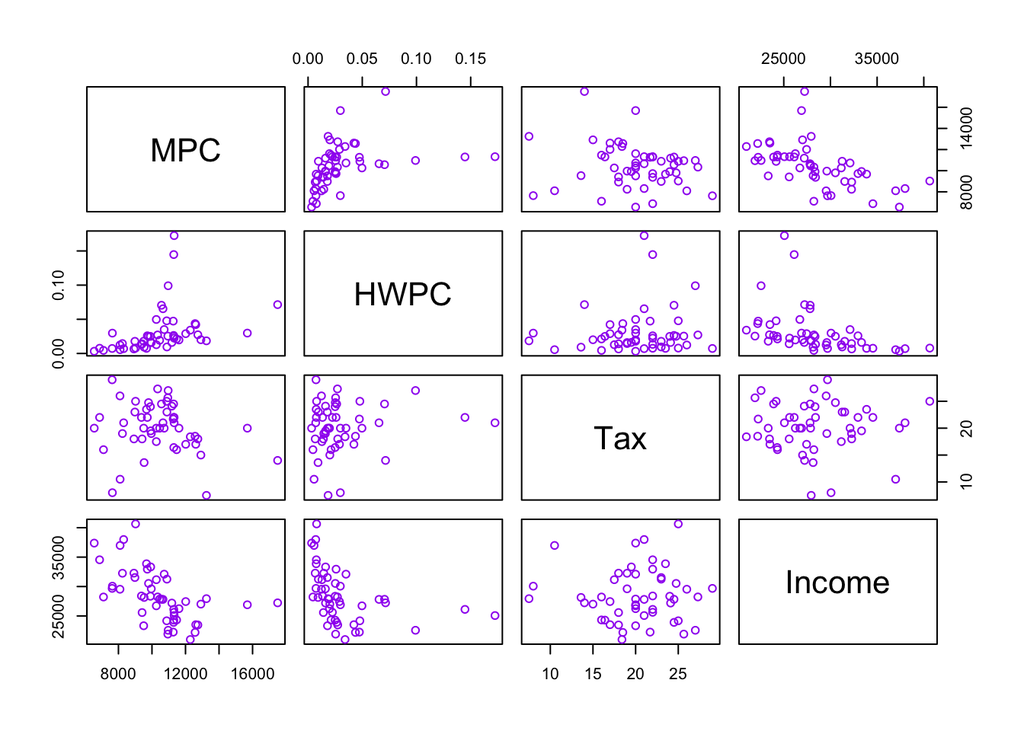

```r
fuel2001$HWPC <- fuel2001$Miles/fuel2001$Pop
# ggpairs(fuel2001,columns=c('MPC','Tax','HWPC','Income'),aes(color=I('purple')))
pairs(MPC~HWPC+Tax+Income,fuel2001,col='purple')
```

The following fancy graphs might make it look like there’s a relationship between the gas tax and the number of miles driven per capita:

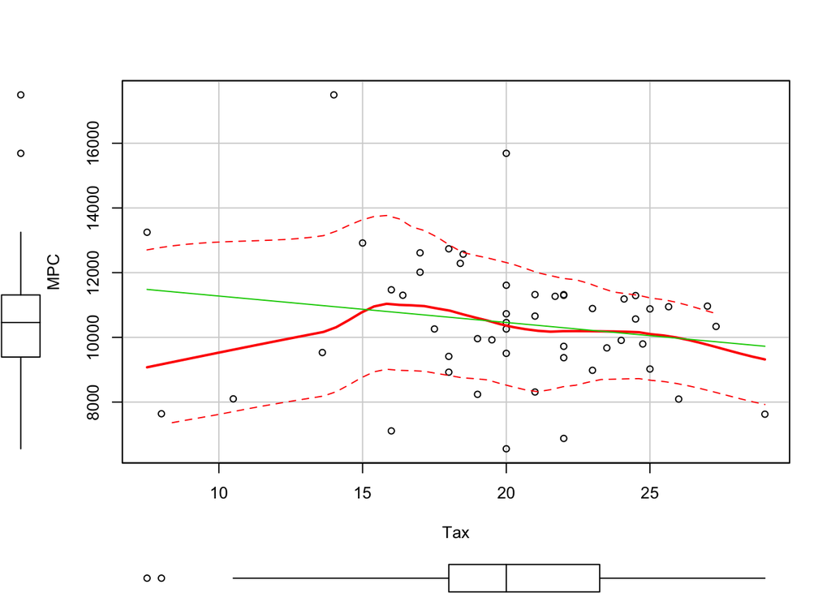

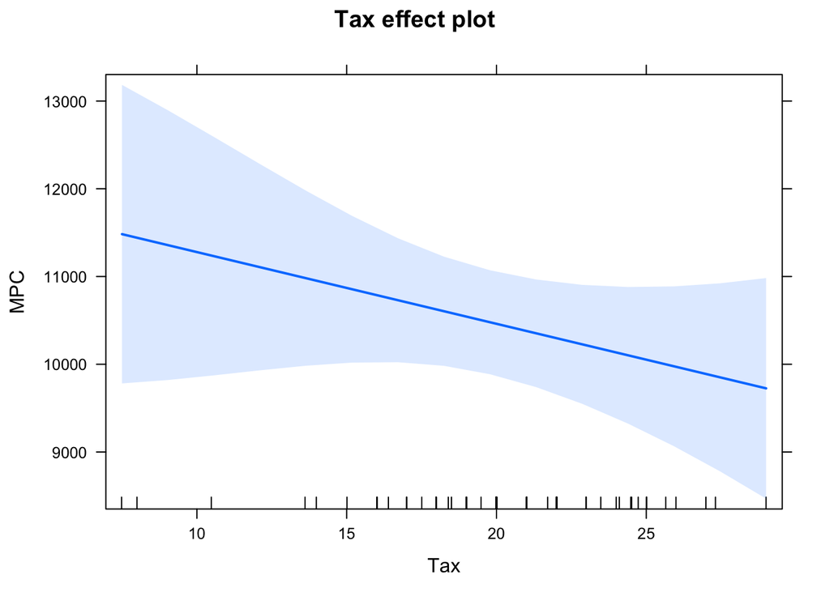

But a quick statistical test casts doubt on this relationship:

```
##
## Call:
## lm(formula = MPC ~ Tax, data = fuel2001)
##
## Residuals:
##     Min      1Q  Median      3Q     Max
## -3905.0 -1121.9   267.4  1041.4  6543.4
##
## Coefficients:
##             Estimate Std. Error t value Pr(>|t|)
## (Intercept) 12096.06    1301.83   9.292 2.18e-12 ***
## Tax           -81.76      63.04  -1.297    0.201
## ---
## Signif. codes:  0 '***' 0.001 '**' 0.01 '*' 0.05 '.' 0.1 ' ' 1
##
## Residual standard error: 2026 on 49 degrees of freedom
## Multiple R-squared:  0.03319,    Adjusted R-squared:  0.01346
## F-statistic: 1.682 on 1 and 49 DF,  p-value: 0.2007
```

The p-value for the test is relatively high (0.2), suggesting that a similarly strong apparent relationship between variables like “MPC”" and “Tax”" would occur just by chance about 20% of the time assuming there is in fact no relationship between the two variables.

#### Exploring the dataset

Let’s back up and get acquainted with the data.

First, to get a handle on some of the main variables, a few plots: